# TermDeposit_Anupam

### Multi,Bi-Variate Analysis

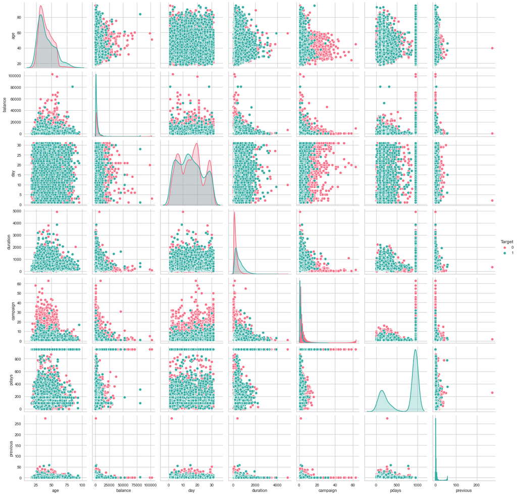

```python
## Pair Plots
sns.pairplot(td, hue="Target", palette="husl")
```

```python
# Binning age
bin_age_edges = [10, 20, 30, 40, 50, 60, 70,80,90, 100]
bin_age_labels = ['10-20', '20-30', '30-40', '40-50', '50-60','60-70', '70-80','80-90','90-100']
td['age'] = pd.cut(td['age'], bins=bin_age_edges , labels=bin_age_labels,include_lowest= True)
```

```
Target      0     1
age
10-20      64    33
20-30    5821  1112
30-40   15875  1812
40-50   10220  1019
50-60    7256   811
60-70     417   284
70-80     213   175
80-90      54    38
90-100      2     5
Target         0         1
age
10-20   0.659794  0.340206
20-30   0.839608  0.160392
30-40   0.897552  0.102448
40-50   0.909334  0.090666
50-60   0.899467  0.100533
60-70   0.594864  0.405136
70-80   0.548969  0.451031
80-90   0.586957  0.413043
90-100  0.285714  0.714286
(9, 2)
```

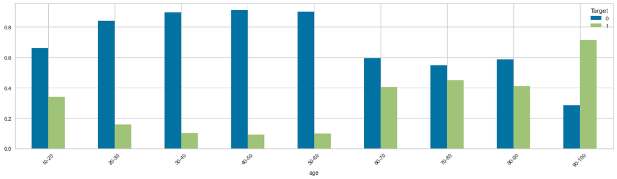

```python
# For Age with Target

Ag_T=pd.crosstab(td['age'],td['Target'],normalize='index')
print(pd.crosstab(td['age'],td['Target']))
print(Ag_T.head(10))
#print(Ag_T.loc[40:])
print(Ag_T.shape)
Ag_T.plot(kind='bar',figsize=(20,5),rot=45)
```

Observation: Term Deposit acceptance percentage is highest in age group 90-100 and above

```
Target            0     1
job
admin.         4540   631
blue-collar    9278   742
entrepreneur   1364   123
housemaid      1131   109
management     8157  1301
retired        1748   516
self-employed  1392   187
services       3785   369
student         669   269
technician     6757   840
unemployed     1101   202
Target                0         1
job
admin.         0.877973  0.122027
blue-collar    0.925948  0.074052
entrepreneur   0.917283  0.082717
housemaid      0.912097  0.087903
management     0.862444  0.137556
retired        0.772085  0.227915
self-employed  0.881571  0.118429
services       0.911170  0.088830
student        0.713220  0.286780
technician     0.889430  0.110570
(11, 2)
```

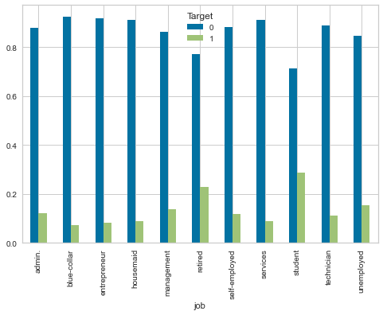

```python
# For Job with Target
Jb_T=pd.crosstab(td['job'],td['Target'],normalize='index')
print(pd.crosstab(td['job'],td['Target']))
print(Jb_T.head(10))
print(Jb_T.shape)
Jb_T.plot(kind='bar')
```

Observation: Term Deposit is more popular(more opted) in Students and then in Retired people

```
Target        0     1
marital
divorced   4585   622
married   24459  2755
single    10878  1912
Target           0         1
marital
divorced  0.880545  0.119455
married   0.898765  0.101235
single    0.850508  0.149492
(3, 2)
```

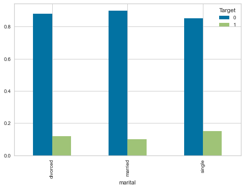

```python
# For Marital Status with Target
Mr_T=pd.crosstab(td['marital'],td['Target'],normalize='index')
print(pd.crosstab(td['marital'],td['Target']))
print(Mr_T.head(10))
print(Mr_T.shape)
Mr_T.plot(kind='bar')
```

Observation: Term Deposit is most popular(more opted) in single people and then in divorsed and least in married.

```
Target         0     1
education
primary     6260   591
secondary  22357  2702
tertiary   11305  1996
Target            0         1
education
primary    0.913735  0.086265
secondary  0.892174  0.107826
tertiary   0.849936  0.150064
(3, 2)
```

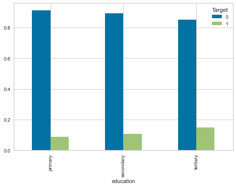

```python
# For Education with Target
Ed_T=pd.crosstab(td['education'],td['Target'],normalize='index')
print(pd.crosstab(td['education'],td['Target']))
print(Ed_T.head(10))
print(Ed_T.shape)
Ed_T.plot(kind='bar')
```

Observation: Term Deposit is more popular(more opted) in people with "tertiary" education and then with the status "secondary"

```
Target       0     1
default
no       39159  5237
yes        763    52

Target          0         1
default
no       0.882039  0.117961
yes      0.936196  0.063804

(2, 2)
```

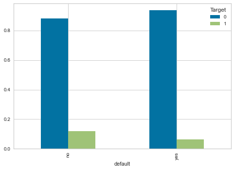

```python
# For Default with Target
Df_T=pd.crosstab(td['default'],td['Target'],normalize='index')
print(pd.crosstab(td['default'],td['Target']));print('')
print(Df_T.head(10));print('')
print(Df_T.shape)
Df_T.plot(kind='bar')
```

Observation: Term Deposit is more popular(more opted) in people with no credit defaults

```
Target       0     1
housing
no       16727  3354
yes      23195  1935

Target          0         1
housing
no       0.832976  0.167024
yes      0.923000  0.077000

(2, 2)
```

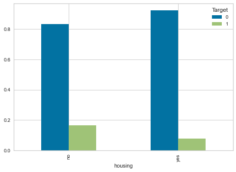

```python
# For Housing with Target
Hs_T=pd.crosstab(td['housing'],td['Target'],normalize='index')
print(pd.crosstab(td['housing'],td['Target']));print('')
print(Hs_T.head(10));print('')
print(Hs_T.shape)
Hs_T.plot(kind='bar')
```

Observation: Term Deposit is more popular(more opted) with people without housing.

```
Target      0     1
loan
no      33162  4805
yes      6760   484

Target         0         1
loan
no      0.873443  0.126557
yes     0.933186  0.066814

(2, 2)
```

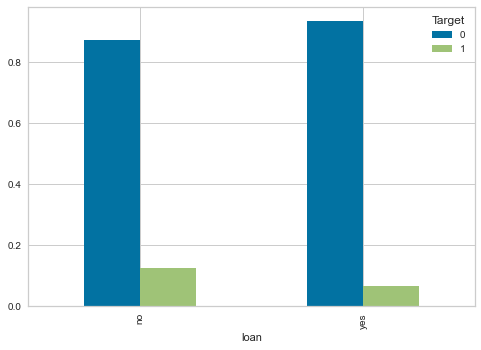

```python
# For Personal Loan with Target
Pl_T=pd.crosstab(td['loan'],td['Target'],normalize='index')
print(pd.crosstab(td['loan'],td['Target']));print('')
print(Pl_T.head(10));print('')
print(Pl_T.shape)
Pl_T.plot(kind='bar')
```

Observation: Term Deposit is more popular(more opted) with people without personal loan.

```python
# Binning for Balance
bin_edges = [0, 1000, 2000, 3000, 4000, 5000,6000,7000,8000,9000,10000,11000,12000,110000]
bin_labels = ['0-1000', '1000-2000', '2000-3000', '3000-4000', '4000-5000','5000-6000','6000-7000','7000-8000','8000-9000',
              '9000-10000','10000-11000','11000-12000','12000-110000']
td['balance'] = pd.cut(td['balance'], bins=bin_edges , labels=bin_labels,include_lowest=True)
```

```python
td['balance'].value_counts()
```

```
0-1000          30580
1000-2000        6130
2000-3000        2890
3000-4000        1713
4000-5000        1053
5000-6000         737
12000-110000      570
6000-7000         482
7000-8000         347
8000-9000         286
9000-10000        164
10000-11000       151
11000-12000       108
Name: balance, dtype: int64
```

```
Target            0     1
balance
0-1000        27539  3041
1000-2000      5291   839
2000-3000      2398   492
3000-4000      1414   299
4000-5000       876   177
5000-6000       615   122
6000-7000       419    63
7000-8000       286    61
8000-9000       250    36
9000-10000      140    24
10000-11000     118    33
11000-12000      86    22
12000-110000    490    80

Target               0         1
balance
0-1000        0.900556  0.099444
1000-2000     0.863132  0.136868
2000-3000     0.829758  0.170242
3000-4000     0.825452  0.174548
4000-5000     0.831909  0.168091
5000-6000     0.834464  0.165536
6000-7000     0.869295  0.130705
7000-8000     0.824207  0.175793
8000-9000     0.874126  0.125874
9000-10000    0.853659  0.146341
10000-11000   0.781457  0.218543
11000-12000   0.796296  0.203704
12000-110000  0.859649  0.140351

(13, 2)
```

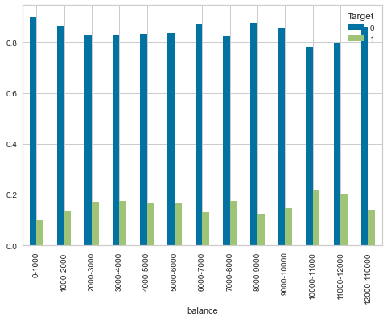

```python
# For balance with Target
Bl_T=pd.crosstab(td['balance'],td['Target'],normalize='index')
print(pd.crosstab(td['balance'],td['Target']));print('')
print(Bl_T.head(15));print('')
print(Bl_T.shape)
Bl_T.plot(kind='bar')
```

Observation: Term Deposit is more popular(more opted) with people with balance category 10000-11000 and then in 11000-12000

```
Target         0     1
contact
cellular   37406  4899
telephone   2516   390

Target            0         1
contact
cellular   0.884198  0.115802
telephone  0.865795  0.134205

(2, 2)
```

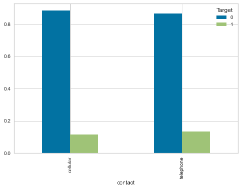

```python
# For Contact with Target
C_T=pd.crosstab(td['contact'],td['Target'],normalize='index')
print(pd.crosstab(td['contact'],td['Target']));print('')
print(C_T.head(10));print('')
print(C_T.shape)
C_T.plot(kind='bar')
```

Observation: People communicated through telephone opted more Term Deposits.

```python
# For poutcome with Target, already dropped this feature

#Po_T=pd.crosstab(td['poutcome'],td['Target'],normalize='index')
#print(pd.crosstab(td['poutcome'],td['Target']));print('')
#print(Po_T.head(10));print('')
#print(Po_T.shape)
#Po_T.plot(kind='bar')
```

```
Target     0    1
day
1        232   90
2       1111  182
3        901  178
4       1215  230
5       1695  215
6       1751  181
7       1660  157
8       1641  201
9       1382  179
10       403  121
11      1298  181
12      1359  244
13      1344  241
```

[output cut: 54 more lines]

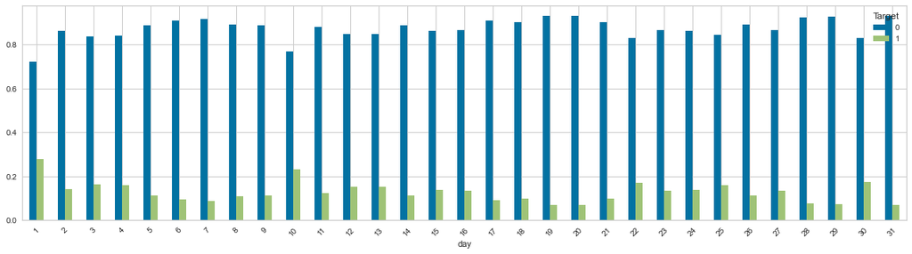

```python
# For Day with Target
Dy_T=pd.crosstab(td['day'],td['Target'],normalize='index')
print(pd.crosstab(td['day'],td['Target']));print('')
print(Dy_T.head(31));print('')
print(Dy_T.shape)
Dy_T.plot(kind='bar',figsize=(20,5),rot=45)
```

Observation: Most useful days for buying Term Deposits was 1st and then 10th and then 30th and then 22nd

```
Target      0    1
month
apr      2355  577
aug      5559  688
dec       114  100
feb      2208  441
jan      1261  142
jul      6268  627
jun      4795  546
mar       229  248
may     12841  925
nov      3567  403
oct       415  323
sep       310  269

Target         0         1
month
apr     0.803206  0.196794
aug     0.889867  0.110133
dec     0.532710  0.467290
feb     0.833522  0.166478
jan     0.898788  0.101212
jul     0.909065  0.090935
jun     0.897772  0.102228
mar     0.480084  0.519916
may     0.932805  0.067195
nov     0.898489  0.101511
oct     0.562331  0.437669
sep     0.535406  0.464594

(12, 2)
```

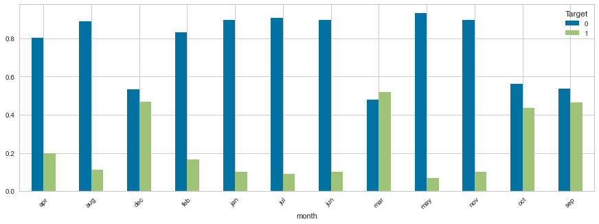

```python
# For Month with Target
Mn_T=pd.crosstab(td['month'],td['Target'],normalize='index')
print(pd.crosstab(td['month'],td['Target']));print('')
print(Mn_T.head(12));print('')
print(Mn_T.shape)
Mn_T.plot(kind='bar',figsize=(15,5),rot=45)
```

Observation: People contacted during month of Mar bought more Term Deposits, followed by month of Dec, Sep and Oct giving good conversions for the bank

```python
# Binning for campaign
bin_edges_cam = [1, 5, 10, 15, 20, 25, 30, 35, 40,45,50,55,60,65]
bin_labels_cam = ['1-5','5-10','10-15','15-20','20-25','25-30','30-35','35-40','40-45','45-50','50-55','55-60','60-65']
td['campaign'] = pd.cut(td['campaign'], bins=bin_edges_cam , labels=bin_labels_cam, include_lowest= True)
```

```
Target        0     1
campaign
1-5       35820  5036
5-10       2953   206
10-15       632    34
15-20       277     9
20-25       120     2
25-30        62     1
30-35        35     1
35-40        10     0
40-45         6     0
45-50         3     0
50-55         2     0
55-60         1     0
60-65         1     0

Target           0         1
campaign
1-5       0.876738  0.123262
5-10      0.934789  0.065211
10-15     0.948949  0.051051
15-20     0.968531  0.031469
30-35     0.972222  0.027778
20-25     0.983607  0.016393
25-30     0.984127  0.015873
35-40     1.000000  0.000000
40-45     1.000000  0.000000
45-50     1.000000  0.000000
50-55     1.000000  0.000000
55-60     1.000000  0.000000
60-65     1.000000  0.000000

(13, 2)
```

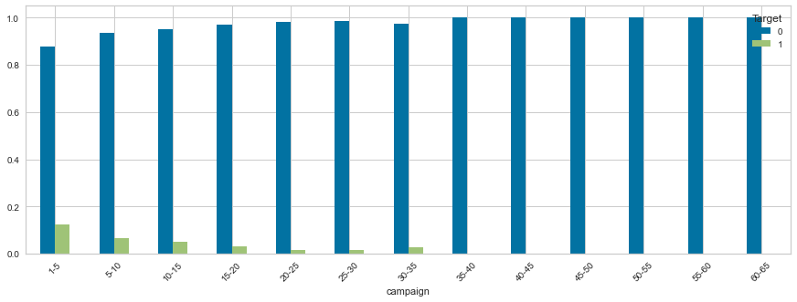

```python
# For campaign with Target
Cm_T=pd.crosstab(td['campaign'],td['Target'],normalize='index')
print(pd.crosstab(td['campaign'],td['Target']).head(40));print('')
#print(Cm_T.head())
print(Cm_T.sort_values(by=1,ascending=False));print('')
print(Cm_T.shape)
Cm_T.plot(kind='bar',figsize=(15,5),rot=45)
#Cm_T.sort_values(by='2',ascending=False)
```

Observation: People contacted once got more Term Deposit, as no of calls increases the tendency to not go for Term Deposit is inceasing.

```python
# For pdays V/S Target

bin_edges2 = [0, 100, 200, 300, 400,500,600,700,800,900,1000]
bin_labels2 = ['0-100','100-200','200-300','300-400','400-500','500-600','600-700','700-800','800-900','900-1000']
td['pdays'] = pd.cut(td['pdays'], bins=bin_edges2 , labels=bin_labels2, include_lowest= True)
```

```
Target        0     1
pdays
0-100       815   622
100-200    2121   745
200-300    1288   196
300-400    2009   227
400-500      57    71
500-600      29    25
600-700      13     6
700-800      14     8
800-900       6     5
900-1000  33570  3384

Target           0         1
pdays
0-100     0.567154  0.432846
100-200   0.740056  0.259944
200-300   0.867925  0.132075
300-400   0.898479  0.101521
400-500   0.445312  0.554688
500-600   0.537037  0.462963
600-700   0.684211  0.315789
700-800   0.636364  0.363636
800-900   0.545455  0.454545
900-1000  0.908427  0.091573

(10, 2)
```

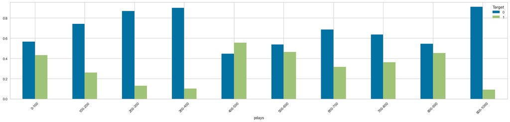

```python
# For pdays with Target
Pd_T=pd.crosstab(td['pdays'],td['Target'],normalize='index')
print(pd.crosstab(td['pdays'],td['Target']));print('')
print(Pd_T.head(12));print('')
print(Pd_T.shape)
Pd_T.plot(kind='bar',figsize=(25,5),rot=45)
```

Observation: People who were contacted 400-500 days back were the most accepting the Term Credit

```python
#bin_edges1 = [0, 100, 200, 300, 400, 500,5000]
#bin_labels1 = ['0-100', '100-200', '200-300', '300-400', '400-500', '>500']
bin_edges1 = [0, 100, 200, 300, 400, 500, 600, 700, 800, 900, 1000,1100,1200,1300,1400,5000]
bin_labels1 = ['0-100', '100-200', '200-300', '300-400', '400-500', '500-600',
              '600-700', '700-800', '800-900', '900-1000', '1000-1100','1100-1200',
              '1200-1300','1300-1400','1400-5000']
td['duration'] = pd.cut(td['duration'], bins=bin_edges1 , labels=bin_labels1, include_lowest= True)
```

```
Target         0    1
duration
0-100      10766  117
100-200    13219  770
200-300     7121  944
300-400     3750  666
400-500     1972  515
500-600     1137  444
600-700      707  418
700-800      424  312
800-900      248  263
900-1000     152  208
1000-1100    113  164
1100-1200     99  122
1200-1300     56   86
1300-1400     32   70
1400-5000    126  190

Target            0         1
duration
0-100      0.989249  0.010751
100-200    0.944957  0.055043
200-300    0.882951  0.117049
300-400    0.849185  0.150815
400-500    0.792923  0.207077
500-600    0.719165  0.280835
600-700    0.628444  0.371556
700-800    0.576087  0.423913
800-900    0.485323  0.514677
900-1000   0.422222  0.577778
1000-1100  0.407942  0.592058
1100-1200  0.447964  0.552036
1200-1300  0.394366  0.605634
1300-1400  0.313725  0.686275
1400-5000  0.398734  0.601266

(15, 2)
```

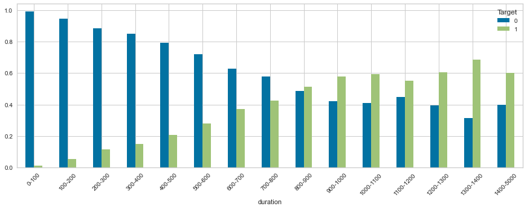

```python
# For duration with Target
Du_T=pd.crosstab(td['duration'],td['Target'],normalize='index')
print(pd.crosstab(td['duration'],td['Target']));print('')
print(Du_T.head(17));print('')
print(Du_T.shape)
Du_T.plot(kind='bar',figsize=(15,5),rot=45)
#Du_T.plot.scatter(x='duration',y='Target')
#td.plot(x='duration',y='Target',kind='scatter')
```

Observation: The more the duration, more is the acceptance of the Term Deposit by the people.

```python
# Binning for previous
bin_edges_prv = [0, 3, 6, 9, 12, 15,18,21,24,27,30,280]
bin_labels_prv = ['0-3','3-6','6-9','9-12','12-15','15-18','18-21','21-24','24-27','27-30','30-280']
td['previous'] = pd.cut(td['previous'], bins=bin_edges_prv , labels=bin_labels_prv, include_lowest= True)
```

```
Target        0     1
previous
0-3       38257  4717
3-6        1075   375
6-9         309   117
9-12        125    51
12-15        62    15
15-18        31     3
18-21        19     4
21-24        17     2
24-27        10     1
27-30         7     2
30-280       10     2

Target           0         1
previous
0-3       0.890236  0.109764
3-6       0.741379  0.258621
6-9       0.725352  0.274648
9-12      0.710227  0.289773
12-15     0.805195  0.194805
15-18     0.911765  0.088235
18-21     0.826087  0.173913
21-24     0.894737  0.105263
24-27     0.909091  0.090909
27-30     0.777778  0.222222
30-280    0.833333  0.166667

(11, 2)
```

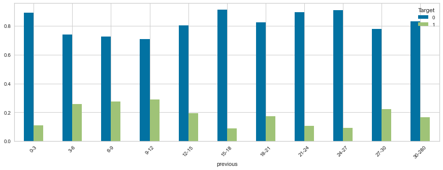

```python
## For previous
Pr_T=pd.crosstab(td['previous'],td['Target'],normalize='index')
print(pd.crosstab(td['previous'],td['Target']));print('')
print(Pr_T.head(31));print('')
print(Pr_T.shape)
Pr_T.plot(kind='bar',figsize=(15,5),rot=45)
```

Observation: Subscription to Term Deposit increased with the the no of contacts done previously in the range of 0-12 previous contacts

### Prepare data for Analytics

```python
# Converting Boolean type Columns having "No, Yes" to "1,2"
mapping ={      "default":   {"no": 0, "yes": 1},
                "housing":   {"no": 0, "yes": 1},
                "loan":      {"no": 0, "yes": 1}
         }
td=td.replace(mapping)
```

```python
td.head(26)
```

|  | age | job | marital | education | default | balance | housing | loan | contact | day | month | duration | campaign | pdays | previous | Target |
| --- | --- | --- | --- | --- | --- | --- | --- | --- | --- | --- | --- | --- | --- | --- | --- | --- |
| 0 | 50-60 | management | married | tertiary | 0 | 2000-3000 | 1 | 0 | cellular | 5 | may | 200-300 | 1-5 | 900-1000 | 0-3 | 0 |
| 1 | 40-50 | technician | single | secondary | 0 | 0-1000 | 1 | 0 | cellular | 5 | may | 100-200 | 1-5 | 900-1000 | 0-3 | 0 |
| 2 | 30-40 | entrepreneur | married | secondary | 0 | 0-1000 | 1 | 1 | cellular | 5 | may | 0-100 | 1-5 | 900-1000 | 0-3 | 0 |
| 3 | 40-50 | blue-collar | married | secondary | 0 | 1000-2000 | 1 | 0 | cellular | 5 | may | 0-100 | 1-5 | 900-1000 | 0-3 | 0 |
| 4 | 30-40 | blue-collar | single | secondary | 0 | 0-1000 | 0 | 0 | cellular | 5 | may | 100-200 | 1-5 | 900-1000 | 0-3 | 0 |
| 5 | 30-40 | management | married | tertiary | 0 | 0-1000 | 1 | 0 | cellular | 5 | may | 100-200 | 1-5 | 900-1000 | 0-3 | 0 |
| 6 | 20-30 | management | single | tertiary | 0 | 0-1000 | 1 | 1 | cellular | 5 | may | 200-300 | 1-5 | 900-1000 | 0-3 | 0 |
| 7 | 40-50 | entrepreneur | divorced | tertiary | 1 | 0-1000 | 1 | 0 | cellular | 5 | may | 300-400 | 1-5 | 900-1000 | 0-3 | 0 |
| 8 | 50-60 | retired | married | primary | 0 | 0-1000 | 1 | 0 | cellular | 5 | may | 0-100 | 1-5 | 900-1000 | 0-3 | 0 |
| 9 | 40-50 | technician | single | secondary | 0 | 0-1000 | 1 | 0 | cellular | 5 | may | 0-100 | 1-5 | 900-1000 | 0-3 | 0 |
| 10 | 40-50 | admin. | divorced | secondary | 0 | 0-1000 | 1 | 0 | cellular | 5 | may | 200-300 | 1-5 | 900-1000 | 0-3 | 0 |
| 11 | 20-30 | admin. | single | secondary | 0 | 0-1000 | 1 | 0 | cellular | 5 | may | 100-200 | 1-5 | 900-1000 | 0-3 | 0 |
| 12 | 50-60 | technician | married | secondary | 0 | 0-1000 | 1 | 0 | cellular | 5 | may | 500-600 | 1-5 | 900-1000 | 0-3 | 0 |
| 13 | 50-60 | technician | married | secondary | 0 | 0-1000 | 1 | 0 | cellular | 5 | may | 0-100 | 1-5 | 900-1000 | 0-3 | 0 |
| 14 | 50-60 | services | married | secondary | 0 | 0-1000 | 1 | 0 | cellular | 5 | may | 100-200 | 1-5 | 900-1000 | 0-3 | 0 |
| 15 | 50-60 | retired | married | primary | 0 | 0-1000 | 1 | 0 | cellular | 5 | may | 300-400 | 1-5 | 900-1000 | 0-3 | 0 |
| 16 | 40-50 | admin. | single | secondary | 0 | 0-1000 | 1 | 0 | cellular | 5 | may | 0-100 | 1-5 | 900-1000 | 0-3 | 0 |
| 17 | 50-60 | blue-collar | married | primary | 0 | 0-1000 | 1 | 0 | cellular | 5 | may | 0-100 | 1-5 | 900-1000 | 0-3 | 0 |
| 18 | 50-60 | retired | married | primary | 0 | 0-1000 | 1 | 0 | cellular | 5 | may | 200-300 | 1-5 | 900-1000 | 0-3 | 0 |
| 19 | 30-40 | services | married | secondary | 0 | 0-1000 | 1 | 0 | cellular | 5 | may | 0-100 | 1-5 | 900-1000 | 0-3 | 0 |
| 20 | 20-30 | blue-collar | married | secondary | 0 | 0-1000 | 1 | 1 | cellular | 5 | may | 200-300 | 1-5 | 900-1000 | 0-3 | 0 |
| 21 | 50-60 | management | married | tertiary | 0 | 0-1000 | 1 | 0 | cellular | 5 | may | 100-200 | 1-5 | 900-1000 | 0-3 | 0 |
| 22 | 30-40 | blue-collar | single | primary | 0 | 0-1000 | 1 | 1 | cellular | 5 | may | 100-200 | 1-5 | 900-1000 | 0-3 | 0 |
| 23 | 20-30 | services | married | secondary | 0 | 0-1000 | 1 | 0 | cellular | 5 | may | 300-400 | 1-5 | 900-1000 | 0-3 | 0 |
| 24 | 30-40 | retired | married | primary | 0 | 0-1000 | 1 | 1 | cellular | 5 | may | 100-200 | 1-5 | 900-1000 | 0-3 | 0 |
| 25 | 40-50 | admin. | married | secondary | 0 | 0-1000 | 1 | 0 | cellular | 5 | may | 100-200 | 1-5 | 900-1000 | 0-3 | 0 |

```python
td.isnull().sum()
```

```
age          0
job          0
marital      0
education    0
default      0
balance      0
housing      0
loan         0
contact      0
day          0
month        0
duration     0
campaign     0
pdays        0
previous     0
Target       0
dtype: int64
```

```python
td.dtypes
```

```
age          category
job          category
marital      category
education    category
default         int64
balance      category
housing         int64
loan            int64
contact      category
day             int64
month        category
duration     category
campaign     category
pdays        category
previous     category
Target          int64
dtype: object
```

```python
#oneHotCols=["age","poutcome","job","marital","education","balance","contact","month","duration","pdays",
#            "previous","campaign"]
#td=pd.get_dummies(td, columns=oneHotCols,drop_first=True)
#td=pd.get_dummies(td,drop_first=True)
```

```python
td.info()
```

```
<class 'pandas.core.frame.DataFrame'>
RangeIndex: 45211 entries, 0 to 45210
Data columns (total 16 columns):
age          45211 non-null category
job          45211 non-null category
marital      45211 non-null category
education    45211 non-null category
default      45211 non-null int64
balance      45211 non-null category
housing      45211 non-null int64
loan         45211 non-null int64
contact      45211 non-null category
day          45211 non-null int64
month        45211 non-null category
duration     45211 non-null category
campaign     45211 non-null category
pdays        45211 non-null category
previous     45211 non-null category
Target       45211 non-null int64
dtypes: category(11), int64(5)
memory usage: 2.2 MB
```

```python
## Define X and Y variables

X = td.drop("Target" , axis=1)
y = td.pop("Target")
X=pd.get_dummies(X,drop_first=True)
```

```python
X.info()
```

```
<class 'pandas.core.frame.DataFrame'>
RangeIndex: 45211 entries, 0 to 45210
Data columns (total 95 columns):
default                 45211 non-null int64
housing                 45211 non-null int64
loan                    45211 non-null int64
day                     45211 non-null int64
age_20-30               45211 non-null uint8
age_30-40               45211 non-null uint8
age_40-50               45211 non-null uint8
age_50-60               45211 non-null uint8
age_60-70               45211 non-null uint8
age_70-80               45211 non-null uint8
age_80-90               45211 non-null uint8
age_90-100              45211 non-null uint8
job_blue-collar         45211 non-null uint8
job_entrepreneur        45211 non-null uint8
job_housemaid           45211 non-null uint8
job_management          45211 non-null uint8
job_retired             45211 non-null uint8
job_self-employed       45211 non-null uint8
job_services            45211 non-null uint8
job_student             45211 non-null uint8
job_technician          45211 non-null uint8
job_unemployed          45211 non-null uint8
marital_married         45211 non-null uint8
marital_single          45211 non-null uint8
education_secondary     45211 non-null uint8
education_tertiary      45211 non-null uint8
balance_1000-2000       45211 non-null uint8
balance_2000-3000       45211 non-null uint8
balance_3000-4000       45211 non-null uint8
balance_4000-5000       45211 non-null uint8
balance_5000-6000       45211 non-null uint8
balance_6000-7000       45211 non-null uint8
balance_7000-8000       45211 non-null uint8
balance_8000-9000       45211 non-null uint8
balance_9000-10000      45211 non-null uint8
balance_10000-11000     45211 non-null uint8
balance_11000-12000     45211 non-null uint8
```

[output cut: 45 more lines]

```
pdays_700-800           45211 non-null uint8
pdays_800-900           45211 non-null uint8
pdays_900-1000          45211 non-null uint8
previous_3-6            45211 non-null uint8
previous_6-9            45211 non-null uint8
previous_9-12           45211 non-null uint8
previous_12-15          45211 non-null uint8
previous_15-18          45211 non-null uint8
previous_18-21          45211 non-null uint8
previous_21-24          45211 non-null uint8
previous_24-27          45211 non-null uint8
previous_27-30          45211 non-null uint8
previous_30-280         45211 non-null uint8
dtypes: int64(4), uint8(91)
memory usage: 5.3 MB
```

```python
##Split into training and test set

X_train, X_test, y_train, y_test = train_test_split(X, y, test_size=0.20,random_state=7)
```

## Create the Ensemble Model

## Logistic Regression Model

```python
# Creating Model and fitting it on train data
logreg = LogisticRegression(random_state=7)
logreg.fit(X_train, y_train)
log_scores = cross_val_score(logreg, X_train, y_train, cv=3)
print("Cross Val Mean Score--",log_scores.mean())
```

```
Cross Val Mean Score-- 0.8916998451669985
```

```python
# Predicting the target variable on test data
y_pred = logreg.predict(X_test)
#np.count_nonzero(y_pred == 1)
```

```python
## function to get confusion matrix
def draw_cm(actual,predicted):
    cm = confusion_matrix(actual,predicted)
    sns.heatmap(cm,annot=True,fmt='.2f',xticklabels = [0,1] ,yticklabels = [0,1])
    plt.ylabel('Observed TD Value')
    plt.xlabel('Predicted TD Value')
    plt.show()
```

```
Training accuracy--> 0.8939393939393939

Testing accuracy--> 0.899922592060157

Confusion Matrix:
```

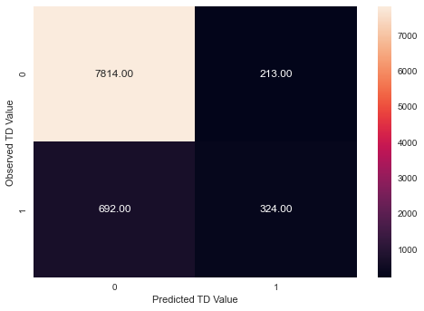

```
None
```

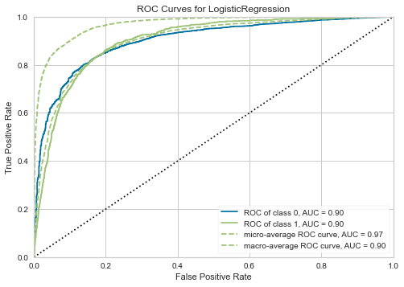

```
Accuracy Score--> 0.899922592060157
Recall Value--> 0.3188976377952756
Precision Value--> 0.6033519553072626
F1 Score--> 0.4172569220862846
ROC Auc Score--> 0.6461810974574982

Classification Report :
              precision    recall  f1-score   support

           0       0.92      0.97      0.95      8027
           1       0.60      0.32      0.42      1016

    accuracy                           0.90      9043
   macro avg       0.76      0.65      0.68      9043
weighted avg       0.88      0.90      0.89      9043
```

```python
print("Training accuracy-->",logreg.score(X_train,y_train))
print('')
print("Testing accuracy-->",logreg.score(X_test, y_test))
print('')
## Printing All releavnt metrics Accuracy, Recall, Precision, f1 score, and roc_auc_score
## Drawing a Heat Map as Confusion Matrix
print('Confusion Matrix:')
print(draw_cm(y_test,y_pred))
roc = ROCAUC(LogisticRegression(random_state=7))
roc.fit(X_train, y_train)
roc.score(X_test, y_test)
roc.show()

print("Accuracy Score-->",accuracy_score(y_test, y_pred))
print("Recall Value-->",recall_score(y_test,y_pred))
print("Precision Value-->",precision_score(y_test,y_pred))
print("F1 Score-->",f1_score(y_test,y_pred))
print("ROC Auc Score-->",roc_auc_score(y_test,y_pred))
print('')
print("Classification Report :")
print(classification_report(y_test,y_pred))
```

```python
#Store the Logistic Reg results in a dataframe for final comparison
resultsDf = pd.DataFrame({'Method':['Logistic Reg'], 'Accuracy': accuracy_score(y_test, y_pred),
                         'Recall': recall_score(y_test,y_pred),'Precision' : precision_score(y_test,y_pred),
                          'F1 Score': f1_score(y_test,y_pred)})
resultsDf
```

|  | Method | Accuracy | Recall | Precision | F1 Score |
| --- | --- | --- | --- | --- | --- |
| 0 | Logistic Reg | 0.899923 | 0.318898 | 0.603352 | 0.417257 |

Observation:

True Positive: 324 Predicted the potential Term Deposit customer and the customer had already accepted the Term Deposit offer

False Positive: 213 Predicted the potential Term Deposit customer, the customer didn't accept it.

True Negative: 7814 Predicted that Term Deposit was not be accepted, and the customer didn't accept.

False: Negative: 692 Predicted that Term Deposit will not be accepted, but the customer went for Term Deposit

Accuracy is quite good. Precision is better in this Model.

```python
# Checking Parameters of logistic regression
logreg.get_params()
```

```
{'C': 1.0,
 'class_weight': None,
 'dual': False,
 'fit_intercept': True,
 'intercept_scaling': 1,
 'l1_ratio': None,
 'max_iter': 100,
 'multi_class': 'auto',
 'n_jobs': None,
 'penalty': 'l2',
 'random_state': 7,
 'solver': 'lbfgs',
 'tol': 0.0001,
 'verbose': 0,
 'warm_start': False}
```

```python
pd.crosstab(y_test, y_pred, rownames=['Actual'], colnames=['Predicted'])
```

| Predicted Actual | 0 | 1 |
| --- | --- | --- |
| 0 | 7814 | 213 |
| 1 | 692 | 324 |

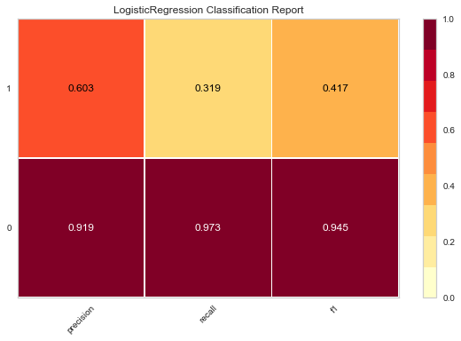

```python
# Visualize model performance with yellowbrick library

viz = ClassificationReport(LogisticRegression(random_state=7))
viz.fit(X_train, y_train)
viz.score(X_test, y_test)
viz.show()
```

## Decision Tree Model

```python
dTree = DecisionTreeClassifier(criterion = 'entropy', max_leaf_nodes=10,random_state=7)
dTree.fit(X_train, y_train)
dTree_scores = cross_val_score(dTree, X_train, y_train, cv=3)
print("Cross Val Mean Score--",dTree_scores.mean())
```

```
Cross Val Mean Score-- 0.8836817075868172
```

```
0.8848982525989825
0.8910759703638174
Accuracy Score--> 0.8910759703638174
Recall Value--> 0.0984251968503937
Precision Value--> 0.591715976331361
F1 Score--> 0.1687763713080169
ROC Auc Score--> 0.5449146041558559
```

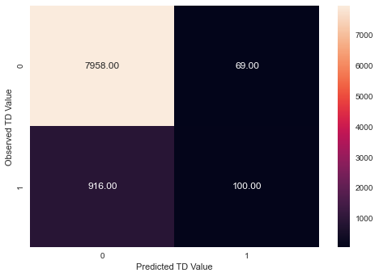

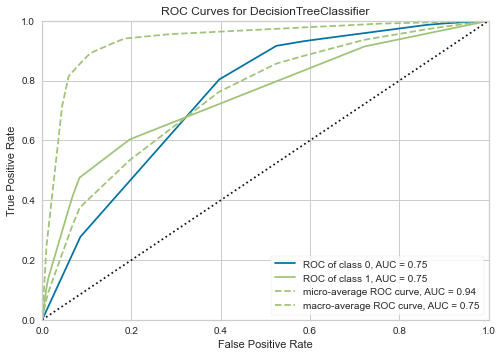

```
Classification Report :
              precision    recall  f1-score   support

           0       0.90      0.99      0.94      8027
           1       0.59      0.10      0.17      1016

    accuracy                           0.89      9043
   macro avg       0.74      0.54      0.56      9043
weighted avg       0.86      0.89      0.85      9043
```

```python
# Scoring Decision Tree
print(dTree.score(X_train, y_train))
print(dTree.score(X_test, y_test))

y_pred1=dTree.predict(X_test)
print("Accuracy Score-->",accuracy_score(y_test, y_pred1))
print("Recall Value-->",recall_score(y_test,y_pred1))
print("Precision Value-->",precision_score(y_test,y_pred1))
print("F1 Score-->",f1_score(y_test,y_pred1))
print("ROC Auc Score-->",roc_auc_score(y_test,y_pred1))

draw_cm(y_test,y_pred1)
roc = ROCAUC(DecisionTreeClassifier(criterion = 'entropy', max_leaf_nodes=10,random_state=7))
roc.fit(X_train, y_train)
roc.score(X_test, y_test)
roc.show()
print("Classification Report :")
print(classification_report(y_test,y_pred1))
```

```python
# Adding Dtree results to dataFrame
resultsDf.loc[1]=["DTree",accuracy_score(y_test, y_pred1),recall_score(y_test,y_pred1),precision_score(y_test,y_pred1),
                 f1_score(y_test,y_pred1)]
resultsDf
```

|  | Method | Accuracy | Recall | Precision | F1 Score |
| --- | --- | --- | --- | --- | --- |
| 0 | Logistic Reg | 0.899923 | 0.318898 | 0.603352 | 0.417257 |
| 1 | DTree | 0.891076 | 0.098425 | 0.591716 | 0.168776 |

Observation:

True Positive: 100 Predicted the potential Term Deposit customer and the customer had already accepted the Term Deposit offer

False Positive: 69 Predicted the potential Term Deposit customer, the customer didn't accept it.

True Negative: 7958 Predicted that Term Deposit was not be accepted, and the customer didn't accept.

False: Negative: 916 Predicted that Term Deposit will not be accepted, but the customer went for Term Deposit

Accuracy is quite good. Precision is good in this Model, but both Precision and Recall are less than Logistic Reg model.

```python
# Checking Parameters of logistic regression
dTree.get_params()
```

```
{'ccp_alpha': 0.0,
 'class_weight': None,
 'criterion': 'entropy',
 'max_depth': None,
 'max_features': None,
 'max_leaf_nodes': 10,
 'min_impurity_decrease': 0.0,
 'min_impurity_split': None,
 'min_samples_leaf': 1,
 'min_samples_split': 2,
 'min_weight_fraction_leaf': 0.0,
 'presort': 'deprecated',
 'random_state': 7,
 'splitter': 'best'}
```

```python
pd.crosstab(y_test, y_pred1, rownames=['Actual'], colnames=['Predicted'])
```

| Predicted Actual | 0 | 1 |
| --- | --- | --- |
| 0 | 7958 | 69 |
| 1 | 916 | 100 |

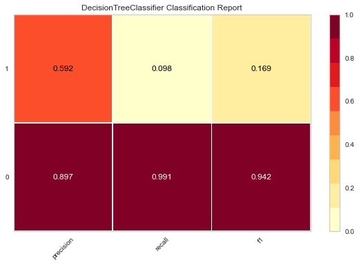

```python
# Visualize model performance with yellowbrick library
viz = ClassificationReport(DecisionTreeClassifier(criterion = 'entropy', max_leaf_nodes=10,random_state=7))
viz.fit(X_train, y_train)
viz.score(X_test, y_test)
viz.show()
```

## Ensemble - Bagging

```python
from sklearn.ensemble import BaggingClassifier
#bgcl = BaggingClassifier(base_estimator=dTree, n_estimators=50,random_state=1)
bgcl= BaggingClassifier(n_estimators=50, max_samples= .7, bootstrap=True, oob_score=True, random_state=22)
bgcl = bgcl.fit(X_train, y_train)
bgcl_scores = cross_val_score(bgcl, X_train, y_train, cv=3)
print("Cross Val Mean Score--",bgcl_scores.mean())
```

```
Cross Val Mean Score-- 0.8887137801371378
```

```
Training Score-- 0.9899358548993585
Testing Score-- 0.8961627778392126
Accuracy Score--> 0.8961627778392126
Recall Value--> 0.41732283464566927
Precision Value--> 0.5499351491569391
F1 Score--> 0.47453833240067156
ROC Auc Score--> 0.6870468664320909
```

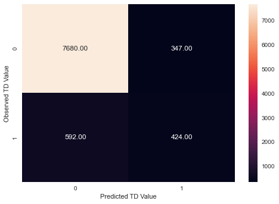

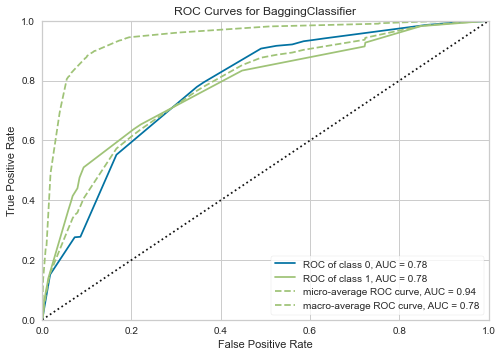

```
Classification Report :
              precision    recall  f1-score   support

           0       0.93      0.96      0.94      8027
           1       0.55      0.42      0.47      1016

    accuracy                           0.90      9043
   macro avg       0.74      0.69      0.71      9043
weighted avg       0.89      0.90      0.89      9043
```

```python
# Scoring Bagging
print("Training Score--",bgcl.score(X_train, y_train))
print("Testing Score--",bgcl.score(X_test, y_test))

y_pred_bgcl=bgcl.predict(X_test)
print("Accuracy Score-->",accuracy_score(y_test, y_pred_bgcl))
print("Recall Value-->",recall_score(y_test,y_pred_bgcl))
print("Precision Value-->",precision_score(y_test,y_pred_bgcl))
print("F1 Score-->",f1_score(y_test,y_pred_bgcl))
print("ROC Auc Score-->",roc_auc_score(y_test,y_pred_bgcl))

draw_cm(y_test,y_pred_bgcl)
roc = ROCAUC(BaggingClassifier(base_estimator=dTree, n_estimators=50,random_state=1))
roc.fit(X_train, y_train)
roc.score(X_test, y_test)
roc.show()

print("Classification Report :")
print(classification_report(y_test,y_pred_bgcl))
```

```python
# Adding Bagging results to dataFrame
resultsDf.loc[2]=["Bagging",accuracy_score(y_test, y_pred_bgcl),recall_score(y_test,y_pred_bgcl),precision_score(y_test,y_pred_bgcl),
                 f1_score(y_test,y_pred_bgcl)]
resultsDf
```

|  | Method | Accuracy | Recall | Precision | F1 Score |
| --- | --- | --- | --- | --- | --- |
| 0 | Logistic Reg | 0.899923 | 0.318898 | 0.603352 | 0.417257 |
| 1 | DTree | 0.891076 | 0.098425 | 0.591716 | 0.168776 |
| 2 | Bagging | 0.896163 | 0.417323 | 0.549935 | 0.474538 |

Observation:

True Positive: 424 Predicted the potential Term Deposit customer and the customer had already accepted the Term Deposit offer

False Positive: 347 Predicted the potential Term Deposit customer, the customer didn't accept it.

True Negative: 7680 Predicted that Term Deposit was not be accepted, and the customer didn't accept.

False: Negative: 592 Predicted that Term Deposit will not be accepted, but the customer went for Term Deposit

Accuracy is better than DTREE. Recall is better than all other Models.

```python
pd.crosstab(y_test, y_pred_bgcl, rownames=['Actual'], colnames=['Predicted'])
```

| Predicted Actual | 0 | 1 |
| --- | --- | --- |
| 0 | 7680 | 347 |
| 1 | 592 | 424 |

[figure not shown]

```python
# Visualize model performance with yellowbrick library
viz = ClassificationReport(BaggingClassifier(base_estimator=dTree, n_estimators=50,random_state=1))
viz.fit(X_train, y_train)
viz.score(X_test, y_test)
viz.show()
```

## Ensemble - AdaBoost

```python
from sklearn.ensemble import AdaBoostClassifier
abcl = AdaBoostClassifier(n_estimators=10, random_state=1)
abcl = abcl.fit(X_train, y_train)
abcl_scores = cross_val_score(abcl, X_train, y_train, cv=3)
print("Cross Val Mean Score--",abcl_scores.mean())
```

```
Cross Val Mean Score-- 0.8863083388630834
```

```
Training Score-- 0.8861977438619775
Testing Score-- 0.8922923808470641
Accuracy Score--> 0.8922923808470641
Recall Value--> 0.1309055118110236
Precision Value--> 0.59375
F1 Score--> 0.21451612903225806
ROC Auc Score--> 0.5597843866517432
```

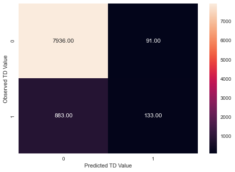

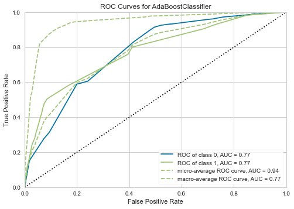

```
Classification Report :
              precision    recall  f1-score   support

           0       0.90      0.99      0.94      8027
           1       0.59      0.13      0.21      1016

    accuracy                           0.89      9043
   macro avg       0.75      0.56      0.58      9043
weighted avg       0.87      0.89      0.86      9043
```

```python
# Scoring AdaBoost
print("Training Score--",abcl.score(X_train, y_train))
print("Testing Score--",abcl.score(X_test, y_test))

y_pred_abcl=abcl.predict(X_test)
print("Accuracy Score-->",accuracy_score(y_test, y_pred_abcl))
print("Recall Value-->",recall_score(y_test,y_pred_abcl))
print("Precision Value-->",precision_score(y_test,y_pred_abcl))
print("F1 Score-->",f1_score(y_test,y_pred_abcl))
print("ROC Auc Score-->",roc_auc_score(y_test,y_pred_abcl))

draw_cm(y_test,y_pred_abcl)
roc = ROCAUC(AdaBoostClassifier(n_estimators=10, random_state=1))
roc.fit(X_train, y_train)
roc.score(X_test, y_test)
roc.show()

print("Classification Report :")
print(classification_report(y_test,y_pred_abcl))
```

```python
# Adding AdaBoost results to dataFrame
resultsDf.loc[3]=["AdaBoost",accuracy_score(y_test, y_pred_abcl),recall_score(y_test,y_pred_abcl),precision_score(y_test,y_pred_abcl),
                 f1_score(y_test,y_pred_abcl)]
resultsDf
```

|  | Method | Accuracy | Recall | Precision | F1 Score |
| --- | --- | --- | --- | --- | --- |
| 0 | Logistic Reg | 0.899923 | 0.318898 | 0.603352 | 0.417257 |
| 1 | DTree | 0.891076 | 0.098425 | 0.591716 | 0.168776 |
| 2 | Bagging | 0.896163 | 0.417323 | 0.549935 | 0.474538 |
| 3 | AdaBoost | 0.892292 | 0.130906 | 0.593750 | 0.214516 |

Observation:

True Positive: 133 Predicted the potential Term Deposit customer and the customer had already accepted the Term Deposit offer

False Positive: 91 Predicted the potential Term Deposit customer, the customer didn't accept it.

True Negative: 7936 Predicted that Term Deposit was not be accepted, and the customer didn't accept.

False: Negative: 883 Predicted that Term Deposit will not be accepted, but the customer went for Term Deposit

Accuracy is better than DTREE, but less than other models. Precision is better than all model but less than Logistic Regression

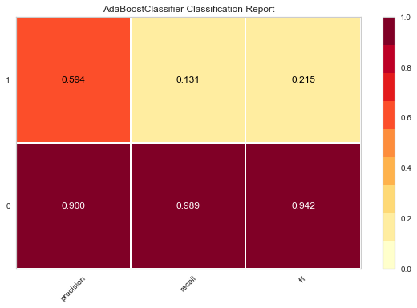

```python
# Visualize model performance with yellowbrick library
viz = ClassificationReport(AdaBoostClassifier(n_estimators=10, random_state=1))
viz.fit(X_train, y_train)
viz.score(X_test, y_test)
viz.show()
```

## Ensemble - GradientBoost

```python
from sklearn.ensemble import GradientBoostingClassifier
gbcl = GradientBoostingClassifier(n_estimators = 50,random_state=1)
gbcl = gbcl.fit(X_train, y_train)
gbcl_scores = cross_val_score(gbcl, X_train, y_train, cv=3)
print("Cross Val Mean Score--",gbcl_scores.mean())
```

```
Cross Val Mean Score-- 0.8869442601194426
```

```
Training Score-- 0.8882437513824375
Testing Score-- 0.8938405396439235
Recall Value--> 0.10531496062992125
Precision Value--> 0.6772151898734177
F1 Score--> 0.18228279386712093
ROC Auc Score--> 0.5494807019419695
```

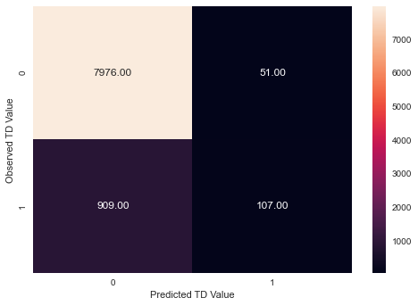

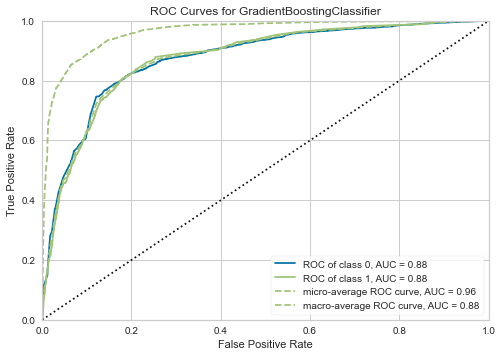

```
Classification Report :
              precision    recall  f1-score   support

           0       0.90      0.99      0.94      8027
           1       0.68      0.11      0.18      1016

    accuracy                           0.89      9043
   macro avg       0.79      0.55      0.56      9043
weighted avg       0.87      0.89      0.86      9043
```

```python
# Scoring Gradient Boost
print("Training Score--",gbcl.score(X_train, y_train))
print("Testing Score--",gbcl.score(X_test, y_test))
#print(gbcl.classes_)
y_pred_gbcl=gbcl.predict(X_test)
print("Recall Value-->",recall_score(y_test,y_pred_gbcl))
print("Precision Value-->",precision_score(y_test,y_pred_gbcl))
print("F1 Score-->",f1_score(y_test,y_pred_gbcl))
print("ROC Auc Score-->",roc_auc_score(y_test,y_pred_gbcl))

draw_cm(y_test,y_pred_gbcl)
roc = ROCAUC(GradientBoostingClassifier(n_estimators = 50,random_state=1))
roc.fit(X_train, y_train)
roc.score(X_test, y_test)
roc.show()

print("Classification Report :")
print(classification_report(y_test,y_pred_gbcl))
```

```python
# Adding GradientBoost results to dataFrame
resultsDf.loc[4]=["GradientBoost",accuracy_score(y_test, y_pred_gbcl),recall_score(y_test,y_pred_gbcl),
                  precision_score(y_test,y_pred_gbcl),f1_score(y_test,y_pred_gbcl)]
resultsDf
```

|  | Method | Accuracy | Recall | Precision | F1 Score |
| --- | --- | --- | --- | --- | --- |
| 0 | Logistic Reg | 0.899923 | 0.318898 | 0.603352 | 0.417257 |
| 1 | DTree | 0.891076 | 0.098425 | 0.591716 | 0.168776 |
| 2 | Bagging | 0.896163 | 0.417323 | 0.549935 | 0.474538 |
| 3 | AdaBoost | 0.892292 | 0.130906 | 0.593750 | 0.214516 |
| 4 | GradientBoost | 0.893841 | 0.105315 | 0.677215 | 0.182283 |

Observation:

True Positive: 107 Predicted the potential Term Deposit customer and the customer had already accepted the Term Deposit offer

False Positive: 51 Predicted the potential Term Deposit customer, the customer didn't accept it.

True Negative: 7976 Predicted that Term Deposit was not be accepted, and the customer didn't accept.

False: Negative: 909 Predicted that Term Deposit will not be accepted, but the customer went for Term Deposit

Accuracy is good but stands 3rd. Precision is better than all model but Recall is less.

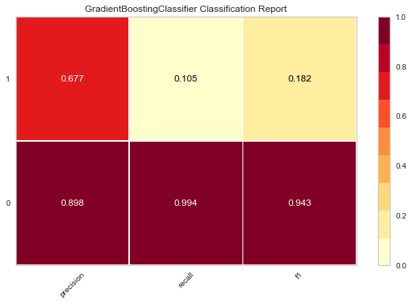

```python
# Visualize model performance with yellowbrick library
viz = ClassificationReport(GradientBoostingClassifier(n_estimators = 50,random_state=1))
viz.fit(X_train, y_train)
viz.score(X_test, y_test)
viz.show()
```

## Comparing Different Models

```python
# Final result Comparision
resultsDf
```

|  | Method | Accuracy | Recall | Precision | F1 Score |
| --- | --- | --- | --- | --- | --- |
| 0 | Logistic Reg | 0.899923 | 0.318898 | 0.603352 | 0.417257 |
| 1 | DTree | 0.891076 | 0.098425 | 0.591716 | 0.168776 |
| 2 | Bagging | 0.896163 | 0.417323 | 0.549935 | 0.474538 |
| 3 | AdaBoost | 0.892292 | 0.130906 | 0.593750 | 0.214516 |
| 4 | GradientBoost | 0.893841 | 0.105315 | 0.677215 | 0.182283 |

### Observation:

The marketing team wants to identify potential customers who are relatively more likely to subscribe term deposit and thus increase their hit ratio, so bank would really like to minimize number of False Positives to minimize the marketing cost not converting to a Term Deposit customer, so "Precision" is the important metric.

Logistic Regression Model has the best accuracy, but Gradient Boost has the best Precision in all other models compared. Since, Precision is the metric required, Gradient Boost is the best Ensemble Model for this dataset.